# Исследование мобильного приложения

Задачами данного проекта является анализ пользовательской активности мобильного приложения по продаже продуктов питания, а также исследование результатов A/A/B-эксперимента, проведенного для тестирования нового шрифта приложения.

## Цели проекта

- Изучить воронку продаж. Исследовать как пользователи доходят до покупки. Сколько пользователей доходит до покупки, а сколько — «застревает» на предыдущих шагах? На каких именно?
- Исследовать результаты A/A/B-эксперимента (предложен новый вариант дизайна). Пользователей разбили на 3 группы: 2 контрольные со старыми шрифтами и одну экспериментальную — с новыми. Выяснить, какой шрифт лучше.

## Выводы исследования

переход к выводам

## Оглавление

1. Изучение данных
1. Предобработка данных
1. Анализ данных
1. Воронка событий

   4.1 Выводы
1. Изучение результатов эксперимента

   5.1 Количество пользователей в каждой группе

   5.2 Проверка контрольных групп

   5.3 Самое популярное событие

   5.4 Расчёт статистической значимости 246 и 247 групп

   5.5 Корректность разбиения на группы

## Изучение данных

```python
# импорт библиотек
import pandas as pd
import numpy as np
import matplotlib.pyplot as plt
from scipy import stats as st
import seaborn as sns
from datetime import datetime, timedelta
import math as mth
import datetime as dt
from plotly import graph_objects as graph
import statsmodels.stats.multitest as smm

sns.set()
```

```python
#расширение содержимого столбцов
pd.set_option('display.max_columns', 30)
```

```python
#чтение датасета
df = pd.read_csv(r'C:\Users\User\My Jupyter Projects\AABtest\logs_exp.csv', sep='\t')
```

```python
#просмотр информации
for i in [df]:
    display(i.info())
    display(i.head())
    display(i.duplicated().sum())
```

```
<class 'pandas.core.frame.DataFrame'>
RangeIndex: 244126 entries, 0 to 244125
Data columns (total 4 columns):
 #   Column          Non-Null Count   Dtype
---  ------          --------------   -----
 0   EventName       244126 non-null  object
 1   DeviceIDHash    244126 non-null  int64
 2   EventTimestamp  244126 non-null  int64
 3   ExpId           244126 non-null  int64
dtypes: int64(3), object(1)
memory usage: 7.5+ MB
```

```
None
```

|  | EventName | DeviceIDHash | EventTimestamp | ExpId |
| --- | --- | --- | --- | --- |
| 0 | MainScreenAppear | 4575588528974610257 | 1564029816 | 246 |
| 1 | MainScreenAppear | 7416695313311560658 | 1564053102 | 246 |
| 2 | PaymentScreenSuccessful | 3518123091307005509 | 1564054127 | 248 |
| 3 | CartScreenAppear | 3518123091307005509 | 1564054127 | 248 |
| 4 | PaymentScreenSuccessful | 6217807653094995999 | 1564055322 | 248 |

```
413
```

```python
#проверка данных столбца
df.EventName.unique()
```

```
array(['MainScreenAppear', 'PaymentScreenSuccessful', 'CartScreenAppear',
       'OffersScreenAppear', 'Tutorial'], dtype=object)
```

```python
#проверка данных столбца
df.ExpId.unique()
```

```
array([246, 248, 247], dtype=int64)
```

### Выводы

В исходном файле 244126 строк. Согласно документации:

- EventName (название события);
- DeviceIDHash (уникальный идентификатор пользователя);
- EventTimestamp (время события);
- ExpId (номер эксперимента).

Возможные вариации столбца EventName:

- MainScreenAppear (стрраница главного экрана);
- Tutorial (обучение);
- OffersScreenAppear (страница предложений);
- CartScreenAppear (страница корзины);
- PaymentScreenSuccessful (страница успешной оплаты).

В столбце ExpId указана принадлежность пользователя к одной из групп. Согласно документации 246 и 247 — контрольные группы, а 248 — экспериментальная.

- группы в файле соответствуют документации;
- названия столбцов не соответствуют стилю snake_case;
- количество дубликатов - 413.

переход к оглавлению

## Предобработка данных

TO DO:

- Заменить названия столбцов;
- Откорректировать типы данных;
- Добавить столбец даты и времени, а также отдельный столбец c датой;
- Разобраться с дубликатами.

```python
#чек
df.columns
```

```
Index(['EventName', 'DeviceIDHash', 'EventTimestamp', 'ExpId'], dtype='object')
```

```python
#изменение названий столбцов
df = df.rename(columns= \
               {'EventName':'event_name', 'DeviceIDHash':'user_id', 'EventTimestamp':'event_time', 'ExpId':'group'})
```

```python
#приведение столбца с датой
df.event_time = pd.to_datetime(df.event_time, unit='s')
```

```python
#добавление отдельного столбца с датой
df['date'] = df.event_time.dt.date
```

```python
#приведение столбца date
df['date'] = df['date'].astype('datetime64')
```

```python
#удаление дубликатов
df = df.drop_duplicates().reset_index(drop=True)
```

```python
#чек фрейма
for i in [df]:
    display(i.info())
    display(i.head())
    display(i.duplicated().sum())
```

```
<class 'pandas.core.frame.DataFrame'>
RangeIndex: 243713 entries, 0 to 243712
Data columns (total 5 columns):
 #   Column      Non-Null Count   Dtype
---  ------      --------------   -----
 0   event_name  243713 non-null  object
 1   user_id     243713 non-null  int64
 2   event_time  243713 non-null  datetime64[ns]
 3   group       243713 non-null  int64
 4   date        243713 non-null  datetime64[ns]
dtypes: datetime64[ns](2), int64(2), object(1)
memory usage: 9.3+ MB
```

```
None
```

|  | event_name | user_id | event_time | group | date |
| --- | --- | --- | --- | --- | --- |
| 0 | MainScreenAppear | 4575588528974610257 | 2019-07-25 04:43:36 | 246 | 2019-07-25 |
| 1 | MainScreenAppear | 7416695313311560658 | 2019-07-25 11:11:42 | 246 | 2019-07-25 |
| 2 | PaymentScreenSuccessful | 3518123091307005509 | 2019-07-25 11:28:47 | 248 | 2019-07-25 |
| 3 | CartScreenAppear | 3518123091307005509 | 2019-07-25 11:28:47 | 248 | 2019-07-25 |
| 4 | PaymentScreenSuccessful | 6217807653094995999 | 2019-07-25 11:48:42 | 248 | 2019-07-25 |

```
0
```

### Выводы

Дубликаты удалены, столбцы переименованы, дата преобразована в объект datetime.

переход к оглавлению

## Анализ данных

TO DO:

- Посчитать число событий в логе;
- Посчитать количество событий на пользователя;
- Найти минимальную и максимальную дату;
- Построить гистограмму по дате и времени;
- Определить момент, когда данные наиболее полные, некорректные даты исключить;
- Посчитать число потерянных данных и пользователей;
- Уточнить факт наличия пользователей во всех 3х группах.

```python
#число событий в логе;
len(df)
```

```
243713
```

```python
#число пользователей
df.user_id.nunique()
```

```
7551
```

```python
#число событий на пользователя
round(len(df) / df.user_id.nunique())
```

```
32
```

```python
#определение периода данных
temp = pd.DataFrame({'min': [df.event_time.min()], 'max':[df.event_time.max()]})
temp.index = ['dates']
temp
```

|  | min | max |
| --- | --- | --- |
| dates | 2019-07-25 04:43:36 | 2019-08-07 21:15:17 |

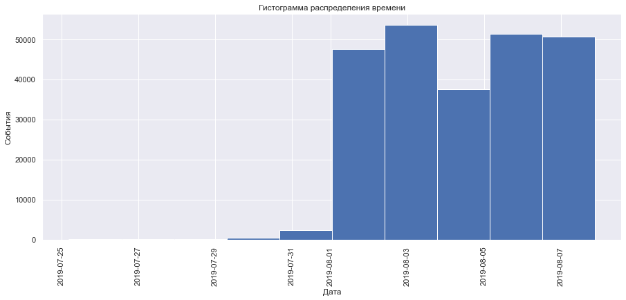

```python
#построение гистограммы
ax = df.event_time.hist(xrot = 90, grid=True, figsize=(15,6))
ax.set_title('Гистограмма распределения времени')
plt.xlabel('Дата')
plt.ylabel('События')
plt.grid(True)
plt.show()
```

1го августа происходит резкий скачок частоты временного интервала, наиболее полные данные находятся в промежутке от 01 августа 2019 года по 07 августа 2019 года.

```python
#исключение первой недели
df_2 = df.loc[df['date'] > '2019-07-31'].reset_index(drop=True)
```

```python
#кол-во исключенных пользователей
df.user_id.nunique() - df_2.user_id.nunique()
```

```
17
```

```python
#доля исключенных пользователей
round((df.user_id.nunique() - df_2.user_id.nunique()) / df.user_id.nunique() * 100, 2)
```

```
0.23
```

```python
#кол-во исключенных событий
len(df) - len(df_2)
```

```
2826
```

```python
#доля исключенных событий
round((len(df) - len(df_2)) / len(df) * 100, 2)
```

```
1.16
```

```python
#чек
df_2.head(3)
```

|  | event_name | user_id | event_time | group | date |
| --- | --- | --- | --- | --- | --- |
| 0 | Tutorial | 3737462046622621720 | 2019-08-01 00:07:28 | 246 | 2019-08-01 |
| 1 | MainScreenAppear | 3737462046622621720 | 2019-08-01 00:08:00 | 246 | 2019-08-01 |
| 2 | MainScreenAppear | 3737462046622621720 | 2019-08-01 00:08:55 | 246 | 2019-08-01 |

```python
#количество уникальных пользователей в группах
df_2.groupby('group')['user_id'].nunique()
```

```
group
246    2484
247    2513
248    2537
Name: user_id, dtype: int64
```

переход к оглавлению

## Воронка событий

TO DO:

- События в логах, как часто встречаются. Отсортировать по частоте;
- Подсчитать сколько пользователей совершали каждое из событий. Отсортировать события по числу пользователей. Посчитать долю пользователей, которые хоть раз совершали событие;
- Предположить, в каком порядке происходят события. Все ли они выстраиваются в последовательную цепочку? (Их не нужно учитывать при расчёте воронки);
- По воронке событий посчитать, какая доля пользователей проходит на следующий шаг воронки;
- Какой шаг теряет больше всего пользователей?
- Какая доля пользователей доходит от первого события до оплаты?

```python
df_2.head(3)
```

|  | event_name | user_id | event_time | group | date |
| --- | --- | --- | --- | --- | --- |
| 0 | Tutorial | 3737462046622621720 | 2019-08-01 00:07:28 | 246 | 2019-08-01 |
| 1 | MainScreenAppear | 3737462046622621720 | 2019-08-01 00:08:00 | 246 | 2019-08-01 |
| 2 | MainScreenAppear | 3737462046622621720 | 2019-08-01 00:08:55 | 246 | 2019-08-01 |

```python
#уникальные значения столбца event_name
df_2.event_name.unique()
```

```
array(['Tutorial', 'MainScreenAppear', 'OffersScreenAppear',
       'CartScreenAppear', 'PaymentScreenSuccessful'], dtype=object)
```

```python
#события, их частота, количество пользователей
df_agg = df_2.groupby('event_name').agg({'event_name':'count', 'user_id':'nunique'})
df_agg = df_agg.rename(columns={'event_name':'count'})
df_agg = df_agg.reset_index().sort_values(by='count', ascending=False)
df_agg = df_agg.rename(columns={'user_id':'users_count'})
df_agg
```

|  | event_name | count | users_count |
| --- | --- | --- | --- |
| 1 | MainScreenAppear | 117328 | 7419 |
| 2 | OffersScreenAppear | 46333 | 4593 |
| 0 | CartScreenAppear | 42303 | 3734 |
| 3 | PaymentScreenSuccessful | 33918 | 3539 |
| 4 | Tutorial | 1005 | 840 |

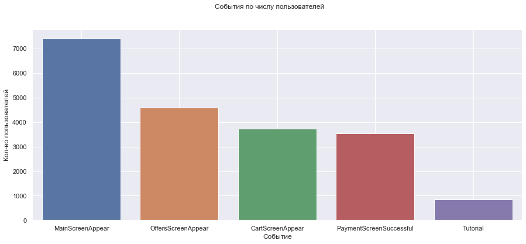

```python
#визуализация
plt.figure(figsize=(15,6))
sns.barplot(data=df_agg, x='event_name', y='users_count')
plt.xlabel('Событие',fontsize=12)
plt.ylabel('Кол-во пользователей',fontsize=12)
plt.grid(True)
plt.suptitle('События по числу пользователей', fontsize=12);
```

```python
#общее кол-во уникальных пользователей
df_2.user_id.nunique()
```

```
7534
```

```python
#добавление столбца с долей пользователей совершивших событие
df_agg['conversion'] = round(df_agg.users_count / df_2.user_id.nunique() * 100, 2)
df_agg
```

|  | event_name | count | users_count | conversion |
| --- | --- | --- | --- | --- |
| 1 | MainScreenAppear | 117328 | 7419 | 98.47 |
| 2 | OffersScreenAppear | 46333 | 4593 | 60.96 |
| 0 | CartScreenAppear | 42303 | 3734 | 49.56 |
| 3 | PaymentScreenSuccessful | 33918 | 3539 | 46.97 |
| 4 | Tutorial | 1005 | 840 | 11.15 |

Порядок событий:

- MainScreenAppear - главный экран;
- Tutorial - обучение работе с приложением (опционально);
- OffersScreenAppear - каталог;
- CartScreenAppear - страница корзины;
- PaymentScreenSuccessful - страница успешной оплаты.

Событие 'Tutorial'- лишнее, потому как прямо не влияет на количество заказов.

```python
#исключение события Tutorial
funnel = df_agg.query('event_name != "Tutorial"')
```

```python
#построение воронки
visual = graph.Figure()
visual = graph.Figure(graph.Funnel(
    y = funnel['event_name'],
    x = funnel['users_count'],
    textinfo = "value+percent initial+percent previous"))
visual.update_layout(title= 'Воронка событий', title_font_size=20,title_x= 0.56, font_size= 15)
visual.show()
```

[interactive chart not shown]

переход к оглавлению

### Выводы по воронке

От первого шага (просмотр главного экрана), где число пользователей - 7419, до последнего (страница успешной оплаты) доходит 3539 человек или 48% в процентном соотношении. Больше всего пользователей теряется при переходе от события "просмотр главного экрана" к событию "просмотр каталога" - 38%.

переход к оглавлению

## Изучение результатов эксперимента

TO DO:

- Определить кол-во пользователей в каждой экспериментальной группе;
- Проверить, находят ли статистические критерии разницу между выборками 246 и 247;
- Выбрать самое популярное событие. Посчитать число пользователей, совершивших это событие в каждой из контрольных групп;
- Посчитать долю пользователей, совершивших это событие. Проверить, будет ли отличие между группами статистически достоверным;
- Проделать то же самое для всех других событий (удобно обернуть проверку в отдельную функцию). Можно ли сказать, что разбиение на группы работает корректно?
- Аналогично поступить с группой с изменённым шрифтом. Сравнить результаты с каждой из контрольных групп в отдельности по каждому событию. Сравните результаты с объединённой контрольной группой. Какие выводы из эксперимента можно сделать?
- Какой уровень значимости был выбран при проверке статистических гипотез выше? Посчитать, сколько проверок статистических гипотез вы сделали. При уровне значимости 0.1 каждый десятый раз можно получать ложный результат. Какой уровень значимости стоит применить?

```python
#чек
df_2.head(3)
```

|  | event_name | user_id | event_time | group | date |
| --- | --- | --- | --- | --- | --- |
| 0 | Tutorial | 3737462046622621720 | 2019-08-01 00:07:28 | 246 | 2019-08-01 |
| 1 | MainScreenAppear | 3737462046622621720 | 2019-08-01 00:08:00 | 246 | 2019-08-01 |
| 2 | MainScreenAppear | 3737462046622621720 | 2019-08-01 00:08:55 | 246 | 2019-08-01 |

### Количество пользователей в каждой группе

246 и 247 — контрольные группы, 248 — экспериментальная.

```python
#исключение Tutorial
df_3 = df_2.query('event_name != "Tutorial"')
```

```python
#определение колоичества пользователей согласно групп
users_grouped = df_3.groupby('group')['user_id'].nunique()
users_grouped
```

```
group
246    2483
247    2512
248    2535
Name: user_id, dtype: int64
```

Число пользователей не равно.

переход к оглавлению

### Проверка контрольных групп

Необходимо провести АА тест между 246 и 247 контрольными группами.

```python
#чек
df_3.head(3)
```

|  | event_name | user_id | event_time | group | date |
| --- | --- | --- | --- | --- | --- |
| 1 | MainScreenAppear | 3737462046622621720 | 2019-08-01 00:08:00 | 246 | 2019-08-01 |
| 2 | MainScreenAppear | 3737462046622621720 | 2019-08-01 00:08:55 | 246 | 2019-08-01 |
| 3 | OffersScreenAppear | 3737462046622621720 | 2019-08-01 00:08:58 | 246 | 2019-08-01 |

```python
#246 контрольная группа
gr_246 = df_3[df_3['group'] == 246]['user_id'].nunique()
gr_246
```

```
2483
```

```python
#247 контрольная группа
gr_247 = df_3[df_3['group'] == 247]['user_id'].nunique()
gr_247
```

```
2512
```

```python
#вычисление процентного соотношения
round(100 - (gr_246 / gr_247 * 100), 2)
```

```
1.15
```

Количество пользователей между группами 246 и 247 различается на 1.15. Согласно критерию успешного АА теста, количество пользователей в различных группах не должно различается более, чем на 1%.

переход к оглавлению

### Самое популярное событие

```python
#создание таблицы с количеством пользователей каждой группы
df_4 = df_3.pivot_table(index='event_name', columns='group', values='user_id', aggfunc='nunique').reset_index()
df_4 = df_4.rename(columns= {246:'246', 247:'247', 248:'248'})
df_4.sort_values(by='246', ascending=False)
```

| group | event_name | 246 | 247 | 248 |
| --- | --- | --- | --- | --- |
| 1 | MainScreenAppear | 2450 | 2476 | 2493 |
| 2 | OffersScreenAppear | 1542 | 1520 | 1531 |
| 0 | CartScreenAppear | 1266 | 1238 | 1230 |
| 3 | PaymentScreenSuccessful | 1200 | 1158 | 1181 |

```python
#доли для каждой группы
df_4['fr_246'] = round(df_4['246'] / users_grouped[246] * 100, 1)
df_4['fr_247'] = round(df_4['247'] / users_grouped[247] * 100, 1)
df_4['fr_248'] = round(df_4['248'] / users_grouped[248] * 100, 1)
```

```python
#чек
df_4 = df_4.sort_values(by='246', ascending=False)
df_4
```

| group | event_name | 246 | 247 | 248 | fr_246 | fr_247 | fr_248 |
| --- | --- | --- | --- | --- | --- | --- | --- |
| 1 | MainScreenAppear | 2450 | 2476 | 2493 | 98.7 | 98.6 | 98.3 |
| 2 | OffersScreenAppear | 1542 | 1520 | 1531 | 62.1 | 60.5 | 60.4 |
| 0 | CartScreenAppear | 1266 | 1238 | 1230 | 51.0 | 49.3 | 48.5 |
| 3 | PaymentScreenSuccessful | 1200 | 1158 | 1181 | 48.3 | 46.1 | 46.6 |

Порядка 1,5% пользователей, в зависимости от группы, не зафиксированы в событии MainScreenAppear (появление главного экрвна).

```python
#визуал воронки по группам
visual = graph.Figure()

visual.add_trace(graph.Funnel(
    name = '246',
    y = df_4['event_name'],
    x = df_4['246'],
    textinfo = "value+percent initial+percent previous"))

visual.add_trace(graph.Funnel(
    name = '247',
    y = df_4['event_name'],
    x = df_4['247'],
    textinfo = "value+percent initial+percent previous"))

visual.add_trace(graph.Funnel(
    name = '248',
    y = df_4['event_name'],
    x = df_4['248'],
    textinfo = "value+percent initial+percent previous"))


visual.update_layout(title= 'Воронка событий по группам', title_font_size=20,title_x= 0.56, font_size= 15)
visual.show()
```

[interactive chart not shown]

Данные 3х групп не равны. Требуется провести ряд тестов для определения статистической значимости различий. Первоначально будет произведено сравнение групп 246 и 247.

- В группе 246 из 2450 пользователей события MainScreenAppear, до успешной оплаты (событие PaymentScreenSuccessful) дошло 1200;
- В группе 247 из 2476 - 1158.

Расчёт статистической значимости предполагает формулировку нулевой и альтернативной гипотез:

H0 - Между выборками нет статистически значимых различий конверсии посетителя в клиента

H1 - Между выборками есть статистически значимые различия конверсии посетителя в клиента

Уровень значимости - 1%

```python
#проверка на пересечение пользователей в разных группах
len(df_3.groupby('user_id')['group'].nunique().reset_index().query('group > 1'))
```

```
0
```

Группы изолированы.

переход к оглавлению

### Расчёт статистической значимости 246 и 247 групп

```python
#чек
df_4
```

| group | event_name | 246 | 247 | 248 | fr_246 | fr_247 | fr_248 |
| --- | --- | --- | --- | --- | --- | --- | --- |
| 1 | MainScreenAppear | 2450 | 2476 | 2493 | 98.7 | 98.6 | 98.3 |
| 2 | OffersScreenAppear | 1542 | 1520 | 1531 | 62.1 | 60.5 | 60.4 |
| 0 | CartScreenAppear | 1266 | 1238 | 1230 | 51.0 | 49.3 | 48.5 |
| 3 | PaymentScreenSuccessful | 1200 | 1158 | 1181 | 48.3 | 46.1 | 46.6 |

```python
#уровень значимости
alpha = 0.01

successful_pay = np.array([df_4.loc[3, '246'], df_4.loc[3, '247']])
main_screen = np.array([df_4.loc[1, '246'], df_4.loc[1, '247']])

# пропорция успехов в первой группе:
p1 = successful_pay[0]/main_screen[0]

# пропорция успехов во второй группе:
p2 = successful_pay[1]/main_screen[1]

# пропорция успехов в комбинированном датасете:
p_combined = (successful_pay[0] + successful_pay[1]) / (main_screen[0] + main_screen[1])

# разница пропорций в датасетах
difference = p1 - p2

# считаем статистику в ст.отклонениях стандартного нормального распределения
z_value = difference / mth.sqrt(p_combined * (1 - p_combined) * (1 / main_screen[0] + 1 / main_screen[1]))

# задаем стандартное нормальное распределение (среднее 0, ст.отклонение 1)
distr = st.norm(0, 1)

p_value = (1 - distr.cdf(abs(z_value))) * 2

print('p-значение: ', p_value)

if p_value < alpha:
    print('Нулевая гипотеза отвергнута')
else:
    print(
        'Нулевая гипотеза не может быть отвергнута'
    )
```

```
p-значение:  0.12044299485641763
Нулевая гипотеза не может быть отвергнута
```

По результатам теста - нет статистически значимой разницы между группами 246 и 247.

переход к оглавлению

### Корректность разбиения на группы

```python
#изменение типа данных в датафрейме
users_grouped.index = users_grouped.index.astype(str)
```

```python
#функция проверки равенства данных
def z_test(group1, group2, alpha):
    p1_event = df_4.loc[event_name, group1]
    p2_event = df_4.loc[event_name, group2]
    p1_users = users_grouped.loc[group1]
    p2_users = users_grouped.loc[group2]

    # пропорция успехов в первой группе:
    p1 = p1_event / p1_users
    # пропорция успехов во второй группе
    p2 = p2_event / p2_users

    # пропорция успехов в комбинированном датасете
    p_combined = (p1_event + p2_event) / (p1_users + p2_users)

    # разница пропорций в датасетах
    difference = p1 - p2

    # считаем статистику в ст.отклонениях стандартного нормального распределения
    z_value = difference / mth.sqrt(p_combined * (1 - p_combined) * (1 / p1_users + 1 / p2_users))

    # задаем стандартное нормальное распределение (среднее 0, ст.отклонение 1)
    distr = st.norm(0, 1)
    p_value = (1 - distr.cdf(abs(z_value))) * 2

    # введем поправку Бонферрони, поделим альфа на число гипотез для всех проверок
    bonferroni_alpha = alpha / 12

    print('Проверка для групп {} и {}, событие: {}, p-значение: {p_value:.2f}'.format(group1, group2, event_name, p_value=p_value))
    if (p_value < bonferroni_alpha):
        print('Нулевая гипотеза отвергнута')
    else:
        print('Нулевая гипотеза не может быть отвергнута')
```

```python
for event_name in df_4.index:
    z_test('246', '247', 0.01)
    print()
```

```
Проверка для групп 246 и 247, событие: 1, p-значение: 0.75
Нулевая гипотеза не может быть отвергнута

Проверка для групп 246 и 247, событие: 2, p-значение: 0.25
Нулевая гипотеза не может быть отвергнута

Проверка для групп 246 и 247, событие: 0, p-значение: 0.23
Нулевая гипотеза не может быть отвергнута

Проверка для групп 246 и 247, событие: 3, p-значение: 0.11
Нулевая гипотеза не может быть отвергнута
```

#### Вывод

По результатам теста, не смотря на различия числа пользователей в группах, разбиение выполнено корректно. Гипотеза H0 верна, между выборками нет статистически значимых различий конверсии посетителя в клиента для всех событий воронки для групп 246 и 247. Минимальное p-значение - 0.11.

переход к оглавлению

## Сравнение групп

В связи с тем, что будет выполнятся множественная проверка гипотез, стоит применить поправку Холма

```python
#функция проверки равенства данных
def z_test2(group1, group2, alpha):
    p1_event = df_4.loc[event_name, group1]
    p2_event = df_4.loc[event_name, group2]
    p1_users = users_grouped.loc[group1]
    p2_users = users_grouped.loc[group2]

    # пропорция успехов в первой группе:
    p1 = p1_event / p1_users
    # пропорция успехов во второй группе
    p2 = p2_event / p2_users

    # пропорция успехов в комбинированном датасете
    p_combined = (p1_event + p2_event) / (p1_users + p2_users)

    # разница пропорций в датасетах
    difference = p1 - p2

    # считаем статистику в ст.отклонениях стандартного нормального распределения
    z_value = difference / mth.sqrt(p_combined * (1 - p_combined) * (1 / p1_users + 1 / p2_users))

    # задаем стандартное нормальное распределение (среднее 0, ст.отклонение 1)
    distr = st.norm(0, 1)
    p_value = (1 - distr.cdf(abs(z_value))) * 2

    #задание поправки Холма
    reject, p_adjust, _, _ = smm.multipletests([p_value], alpha=alpha, method='holm')

    #задание поправки Холма
    holm_alpha = p_adjust[0]

    print('Проверка для групп {} и {}, событие: {}, p-значение: {p_value:.2f}'.format(group1, group2, event_name, p_value=p_value))
    if (holm_alpha < alpha):
        print('Нулевая гипотеза отвергнута')
    else:
        print('Нулевая гипотеза не может быть отвергнута')
```

### Сравнение групп 248 (с измененным шрифтом) и 246

```python
#сравнение с группой 246
for event_name in df_4.index:
    z_test2('248', '246', 0.01)
    print()
```

```
Проверка для групп 248 и 246, событие: 1, p-значение: 0.34
Нулевая гипотеза не может быть отвергнута

Проверка для групп 248 и 246, событие: 2, p-значение: 0.21
Нулевая гипотеза не может быть отвергнута

Проверка для групп 248 и 246, событие: 0, p-значение: 0.08
Нулевая гипотеза не может быть отвергнута

Проверка для групп 248 и 246, событие: 3, p-значение: 0.22
Нулевая гипотеза не может быть отвергнута
```

#### Вывод

По результатам теста, также нельзя отвергнуть нулевую гипотезу. Минимальное p-значение - 0.08.

### Сравнение групп 248 (с измененным шрифтом) и 247

```python
#сравнение с группой 246
for event_name in df_4.index:
    z_test2('248', '247', 0.01)
    print()
```

```
Проверка для групп 248 и 247, событие: 1, p-значение: 0.52
Нулевая гипотеза не может быть отвергнута

Проверка для групп 248 и 247, событие: 2, p-значение: 0.93
Нулевая гипотеза не может быть отвергнута

Проверка для групп 248 и 247, событие: 0, p-значение: 0.59
Нулевая гипотеза не может быть отвергнута

Проверка для групп 248 и 247, событие: 3, p-значение: 0.73
Нулевая гипотеза не может быть отвергнута
```

#### Вывод

По результатам теста, также нельзя отвергнуть нулевую гипотезу. Минимальное p-значение - 0.52.

## Общий вывод

Задачей исследования являлось определение влияния изменения шрифта на пользовательскую активность.

В исходном файле было 244126 событий, пользователи были разделены на 3 группы 246 и 247 — контрольные группы, в которых версия приложения демонстрировалась без изменений и 248 — экспериментальная, в которой версия приложения демонстрировала с измененным шрифтом.

В ходе изучения воронки событий от первого события (показ главного экрана), где число пользователей - 7419, до последнего (страница успешной оплаты) доходит 3539 человек или 48% в процентном соотношении. Больше всего пользователей теряется при переходе от события "просмотр главного экрана" к событию "просмотр каталога" - 38%. Следует изучить этот момент, с целью повысить процент перехода пользователей ко второму событию - просмотру каталога.

Событие Tutorial - не оказывает влияния на заказы, поэтому оно было исключено.

Число пользователей в группах не было равным, различие в процентном соотношении 246 и 247 контрольных групп - 1.15%, что выше допустимого значения.

При исследовании статистической значимости были сформулированны гипотезы:

- H0 - Между выборками нет статистически значимых различий конверсии посетителя в клиента
- H1 - Между выборками есть статистически значимые различия конверсии посетителя в клиента

В ходе исследования было проведено 13 проверок статистической значимости и нулевая гипотеза не была отклонена. Статистически значимой разницы между группами не выявлено. Следовательно, изменения шрифта не повлияло ни на один этап воронки.

Уровень значимости был определен как 0,01. В ходе исследования минимальное p-значение составило - 0.08. Нулевая гипотеза не была отклонена ни разу. Следовательно увеличение уровня значимости до 0, 05 - не повлияло бы на результат.

Также, в дополнение был применет метод Холма, который способствует большой мощности

переход к оглавлению